# MLS Salary Analysis

#### DSC 550

#### 06/01/2024

*Milestone 1: Data Selection and EDA*

Introduction to Business Problem: In Major League Soccer (MLS), player salaries are intricately tied to their individual abilities and contributions on the field. As in many professional sports leagues, player salaries in MLS are often reflective of a player's skill level, experience, and performance. Talented players who consistently demonstrate exceptional abilities, such as goal-scoring prowess, creative playmaking, or defensive solidity, often command higher salaries compared to their counterparts. This study seeks to evaluate the compensation levels of players in MLS relative to their performance during the 2021 season and their guaranteed salaries for 2022. Focusing solely on player performance in 2021, the study aims to identify instances of players potentially being either overpaid or underpaid. It will investigate whether enhanced performance correlates with projected salary increases for the subsequent season. Additionally, the study intends to analyze seasonal trends for teams to inform roster decisions for the upcoming season.

```python
# import libraries

import pandas as pd
import matplotlib.pyplot as plt
import numpy as np
```

```python
# load data from CSV file to dataframe and ensure it loaded correctly

mls_dataset = pd.read_csv("MLS_pl_2021_stats_w_2022_salaries.csv")
mls_dataset.head()
```

|  | name | club_abb | club | 2021 guaranteed comp. | 2022 guar. comp. | position | birth_city | birth_country | height, cm | weight, kg | ... | accurate_goal_kicks | dive_catch | inaccurate_goal_kicks | penalty_faced | pen_goals_conceded | punches | drops | good_claim | saves_per | goals_against_average |
| --- | --- | --- | --- | --- | --- | --- | --- | --- | --- | --- | --- | --- | --- | --- | --- | --- | --- | --- | --- | --- | --- |
| 0 | Valentin Castellanos | NYC | New York City | 776000.0 | 1076000.0 | Forward | Mendoza | Argentina | 178.0 | 70.0 | ... | 0 | 0 | 0 | 0 | 3 | 0 | 0 | 0 | 0.0 | 0.95 |
| 1 | Ola Kamara | DC | DC United | 420000.0 | 1520000.0 | Forward | NaN | Norway | 185.0 | 82.0 | ... | 0 | 0 | 0 | 0 | 2 | 0 | 0 | 0 | 0.0 | 1.43 |
| 2 | Javier Hernandez | LA | LA Galaxy | 6000000.0 | 7443750.0 | Forward | Guadalajara | Mexico | 175.0 | 73.0 | ... | 0 | 0 | 0 | 0 | 3 | 0 | 0 | 0 | 0.0 | 1.40 |
| 3 | Raul Ruidiaz | SEA | Seattle Sounders | 2100000.0 | 3201120.0 | Forward | Lima | Peru | 169.0 | 65.0 | ... | 0 | 0 | 0 | 0 | 3 | 0 | 0 | 0 | 0.0 | 0.92 |
| 4 | Damir Kreilach | RSL | Real Salt Lake | 1350000.0 | 1762572.0 | Midfielder | Vukovar | Croatia | 186.0 | 79.0 | ... | 0 | 0 | 0 | 0 | 3 | 0 | 0 | 0 | 0.0 | 1.50 |

5 rows × 109 columns

```python
print("The dimension of the table is: ", mls_dataset.shape)
```

```
The dimension of the table is:  (623, 109)
```

```python
print("Descriptive Stats:")
print(mls_dataset.describe())
```

```
Descriptive Stats:
       2021 guaranteed comp.  2022 guar. comp.  height, cm  weight, kg  \
count           6.230000e+02      6.230000e+02  620.000000  618.000000
mean            4.447596e+05      5.008088e+05  180.124194   75.470874
std             6.926729e+05      7.132698e+05    7.448199    7.931430
min             6.354700e+04      6.550000e+04  160.000000   52.000000
25%             8.637500e+04      1.026290e+05  175.000000   70.000000
50%             2.230000e+05      2.912500e+05  180.000000   75.000000
75%             5.013625e+05      5.966820e+05  185.000000   81.000000
max             6.300000e+06      7.443750e+06  201.000000  102.000000

       games_played  game_started         mins      sub_on  total_sub_off  \
count    623.000000    623.000000   623.000000  623.000000      623.00000
mean      17.528090     13.276083  1190.418941    4.252006        4.58427
std       11.415935     10.762005   940.051219    4.709475        5.02299
min        0.000000      0.000000     0.000000    0.000000        0.00000
25%        6.000000      2.000000   240.000000    0.000000        0.00000
50%       20.000000     12.000000  1140.000000    3.000000        3.00000
75%       28.000000     23.000000  2016.500000    7.000000        7.00000
max       34.000000     34.000000  3060.000000   25.000000       25.00000

       total_wins  ...  accurate_goal_kicks  dive_catch  \
count  623.000000  ...           623.000000  623.000000
mean     6.560193  ...            12.727127    0.150883
std      5.056512  ...            54.399729    0.793682
min      0.000000  ...             0.000000    0.000000
25%      2.000000  ...             0.000000    0.000000
50%      6.000000  ...             0.000000    0.000000
75%     10.500000  ...             0.000000    0.000000
max     21.000000  ...           408.000000    8.000000

       inaccurate_goal_kicks  penalty_faced  pen_goals_conceded     punches  \
count              623.00000     623.000000          623.000000  623.000000
mean                 3.23114       0.158909            1.370787    0.467095
std                 14.46810       0.760001            1.499919    2.170792
min                  0.00000       0.000000            0.000000    0.000000
25%                  0.00000       0.000000            0.000000    0.000000
50%                  0.00000       0.000000            1.000000    0.000000
75%                  0.00000       0.000000            2.000000    0.000000
max                130.00000       6.000000            7.000000   22.000000

            drops  good_claim   saves_per  goals_against_average
count  623.000000  623.000000  513.000000             537.000000
mean     0.123596    0.598716    6.528558               1.418026
std      0.638380    2.697408   19.946084               0.863350
min      0.000000    0.000000    0.000000               0.000000
25%      0.000000    0.000000    0.000000               1.040000
50%      0.000000    0.000000    0.000000               1.350000
75%      0.000000    0.000000    0.000000               1.650000
max      8.000000   22.000000  100.000000              15.000000

[8 rows x 102 columns]
```

Dataset Overview: This dataset comprises publicly accessible information on soccer players competing in Major League Soccer during the 2021 season. It includes performance metrics such as total wins, losses, draws, goals scored, assists, accurate passes, successful tackles, and saves, among others. Additionally, the dataset provides essential player details such as name, club affiliation, compensation, and position.

```python
# find the number of players for each playing position

position_counts = mls_dataset['position'].value_counts()
print(position_counts)
```

```
position
Midfielder    220
Defender      199
Forward       130
Goalkeeper     74
Name: count, dtype: int64
```

```python
# can also do the same using groupby

grouped_by_position = mls_dataset.groupby('position').size()
grouped_by_position
```

```
position
Defender      199
Forward       130
Goalkeeper     74
Midfielder    220
dtype: int64
```

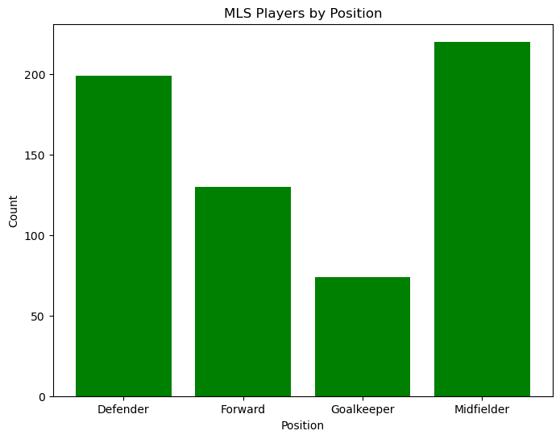

```python
# create a bar graph showing the counts of players by position

plt.figure(figsize = (8, 6))
plt.bar(grouped_by_position.index, grouped_by_position.values, color = 'green')
plt.xlabel('Position')
plt.ylabel('Count')
plt.title('MLS Players by Position')
plt.show()
```

Graph 1: I began with a straightforward visualization, aiming to illustrate the distribution of player positions in Major League Soccer (MLS). The graph reveals a notable disparity in representation among positions, with goalkeepers being the least represented. This observation aligns with the inherent nature of soccer, where each team typically fields only one goalkeeper at a time.

```python
# create a dataframe that reflects just the forwards

forwards_df = mls_dataset[mls_dataset['position'] == 'Forward']
forwards_df
```

|  | name | club_abb | club | 2021 guaranteed comp. | 2022 guar. comp. | position | birth_city | birth_country | height, cm | weight, kg | ... | accurate_goal_kicks | dive_catch | inaccurate_goal_kicks | penalty_faced | pen_goals_conceded | punches | drops | good_claim | saves_per | goals_against_average |
| --- | --- | --- | --- | --- | --- | --- | --- | --- | --- | --- | --- | --- | --- | --- | --- | --- | --- | --- | --- | --- | --- |
| 0 | Valentin Castellanos | NYC | New York City | 776000.0 | 1076000.0 | Forward | Mendoza | Argentina | 178.0 | 70.0 | ... | 0 | 0 | 0 | 0 | 3 | 0 | 0 | 0 | 0.0 | 0.95 |
| 1 | Ola Kamara | DC | DC United | 420000.0 | 1520000.0 | Forward | NaN | Norway | 185.0 | 82.0 | ... | 0 | 0 | 0 | 0 | 2 | 0 | 0 | 0 | 0.0 | 1.43 |
| 2 | Javier Hernandez | LA | LA Galaxy | 6000000.0 | 7443750.0 | Forward | Guadalajara | Mexico | 175.0 | 73.0 | ... | 0 | 0 | 0 | 0 | 3 | 0 | 0 | 0 | 0.0 | 1.40 |
| 3 | Raul Ruidiaz | SEA | Seattle Sounders | 2100000.0 | 3201120.0 | Forward | Lima | Peru | 169.0 | 65.0 | ... | 0 | 0 | 0 | 0 | 3 | 0 | 0 | 0 | 0.0 | 0.92 |
| 6 | Daniel Salloi | SKC | Sporting Kansas City | 456667.0 | 506667.0 | Forward | Siófok | Hungary | 185.0 | 70.0 | ... | 0 | 0 | 0 | 0 | 0 | 0 | 0 | 0 | 0.0 | 1.10 |
| ... | ... | ... | ... | ... | ... | ... | ... | ... | ... | ... | ... | ... | ... | ... | ... | ... | ... | ... | ... | ... | ... |
| 592 | Christian Torres | LAFC | LAFC | 90968.0 | 101230.0 | Forward | Fontana | USA | 178.0 | 69.0 | ... | 0 | 0 | 0 | 0 | 0 | 0 | 0 | 0 | NaN | NaN |
| 593 | Dantouma Toure | COL | Colorado Rapids | 78165.0 | 80118.0 | Forward | NaN | Guinea | 175.0 | 68.0 | ... | 0 | 0 | 0 | 0 | 0 | 0 | 0 | 0 | NaN | 0.00 |
| 607 | Patrick Weah | MIN | Minnesota United | 76733.0 | 79910.0 | Forward | NaN | Liberia | 185.0 | 84.0 | ... | 0 | 0 | 0 | 0 | 0 | 0 | 0 | 0 | NaN | 0.00 |
| 613 | Tyler Wolff | ATL | Atlanta United | 79500.0 | 114500.0 | Forward | NaN | USA | 175.0 | 70.0 | ... | 0 | 0 | 0 | 0 | 1 | 0 | 0 | 0 | 0.0 | 2.41 |
| 616 | Darren Yapi | COL | Colorado Rapids | 74380.0 | 76333.0 | Forward | Denver | USA | 185.0 | 79.0 | ... | 0 | 0 | 0 | 0 | 0 | 0 | 0 | 0 | NaN | NaN |

130 rows × 109 columns

```python
# sort by most goals

forwards_df_sorted = forwards_df.sort_values(by = 'goals', ascending = False)
forwards_df_sorted.head(10)
```

|  | name | club_abb | club | 2021 guaranteed comp. | 2022 guar. comp. | position | birth_city | birth_country | height, cm | weight, kg | ... | accurate_goal_kicks | dive_catch | inaccurate_goal_kicks | penalty_faced | pen_goals_conceded | punches | drops | good_claim | saves_per | goals_against_average |
| --- | --- | --- | --- | --- | --- | --- | --- | --- | --- | --- | --- | --- | --- | --- | --- | --- | --- | --- | --- | --- | --- |
| 0 | Valentin Castellanos | NYC | New York City | 776000.0 | 1076000.0 | Forward | Mendoza | Argentina | 178.0 | 70.0 | ... | 0 | 0 | 0 | 0 | 3 | 0 | 0 | 0 | 0.0 | 0.95 |
| 1 | Ola Kamara | DC | DC United | 420000.0 | 1520000.0 | Forward | NaN | Norway | 185.0 | 82.0 | ... | 0 | 0 | 0 | 0 | 2 | 0 | 0 | 0 | 0.0 | 1.43 |
| 2 | Javier Hernandez | LA | LA Galaxy | 6000000.0 | 7443750.0 | Forward | Guadalajara | Mexico | 175.0 | 73.0 | ... | 0 | 0 | 0 | 0 | 3 | 0 | 0 | 0 | 0.0 | 1.40 |
| 3 | Raul Ruidiaz | SEA | Seattle Sounders | 2100000.0 | 3201120.0 | Forward | Lima | Peru | 169.0 | 65.0 | ... | 0 | 0 | 0 | 0 | 3 | 0 | 0 | 0 | 0.0 | 0.92 |
| 6 | Daniel Salloi | SKC | Sporting Kansas City | 456667.0 | 506667.0 | Forward | Siófok | Hungary | 185.0 | 70.0 | ... | 0 | 0 | 0 | 0 | 0 | 0 | 0 | 0 | 0.0 | 1.10 |
| 7 | Gustavo Bou | NE | New England Revolutio | 2120000.0 | 2675000.0 | Forward | Entre Ríos | Argentina | 176.0 | 72.0 | ... | 0 | 0 | 0 | 0 | 0 | 0 | 0 | 0 | 0.0 | 1.24 |
| 8 | Johnny Russell | SKC | Sporting Kansas City | 1600000.0 | 2000000.0 | Forward | Glasgow | Scotland | 178.0 | 79.0 | ... | 0 | 0 | 0 | 0 | 2 | 0 | 0 | 0 | 0.0 | 1.30 |
| 9 | Cristian Arango | LAFC | LAFC | 659000.0 | 683000.0 | Forward | Medellín | Colombia | 178.0 | 70.0 | ... | 0 | 0 | 0 | 0 | 0 | 0 | 0 | 0 | 0.0 | 1.67 |
| 11 | Cj Sapong | NSH | Nashville | 427778.0 | 550000.0 | Forward | Manassas | USA | 185.0 | 84.0 | ... | 0 | 0 | 0 | 0 | 2 | 0 | 0 | 0 | 0.0 | 0.89 |
| 12 | Josef Martinez | ATL | Atlanta United | 3891667.0 | 4141667.0 | Forward | Valencia | Venezuela | 172.0 | 74.0 | ... | 0 | 0 | 0 | 0 | 1 | 0 | 0 | 0 | 0.0 | 0.93 |

10 rows × 109 columns

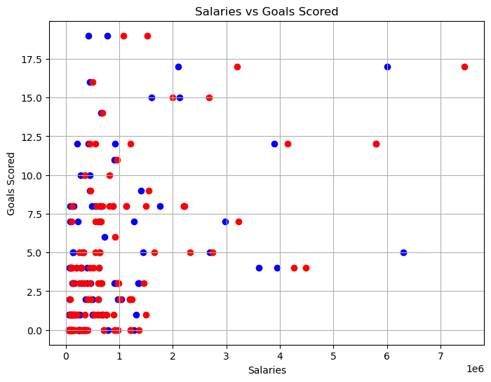

```python
# plot scatterplots for forwards' salaries vs goals scored for both 2021 and 2022 salaries

plt.figure(figsize = (8, 6))
plt.scatter(forwards_df['2021 guaranteed comp.'], forwards_df['goals'], color = 'blue', label = '2021')
plt.scatter(forwards_df['2022 guar. comp.'], forwards_df['goals'], color = 'red', label = '2022')
plt.xlabel('Salaries')
plt.ylabel('Goals Scored')
plt.title('Salaries vs Goals Scored')
plt.grid(True)
plt.show()
```

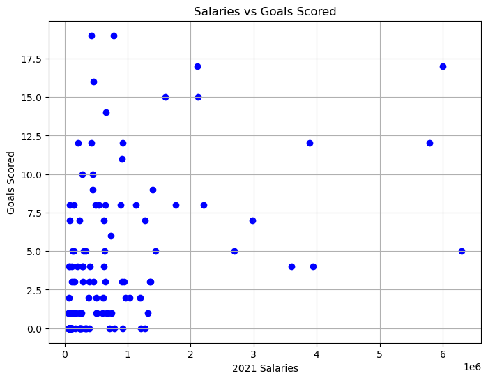

```python
# separate graph for just 2021 salaries vs goals scored by forwards

plt.figure(figsize = (8, 6))
plt.scatter(forwards_df['2021 guaranteed comp.'], forwards_df['goals'], color = 'blue')
plt.xlabel('2021 Salaries')
plt.ylabel('Goals Scored')
plt.title('Salaries vs Goals Scored')
plt.grid(True)
plt.show()
```

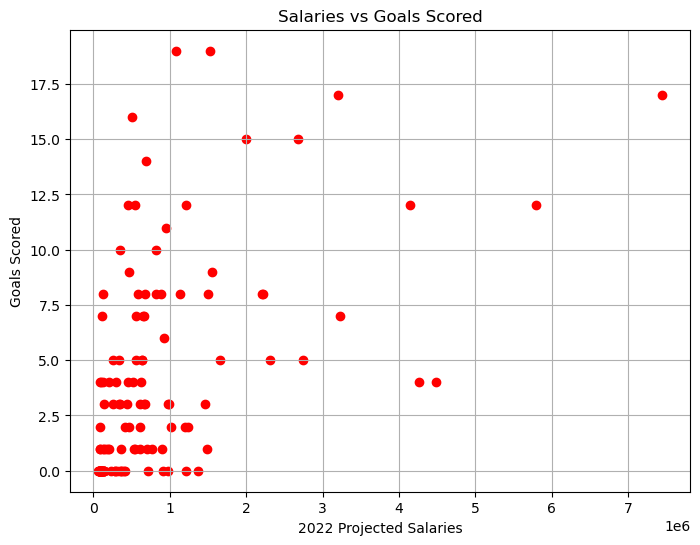

```python
# # separate graph for just 2022 projected salaries vs goals scored by forwards in 2021

plt.figure(figsize = (8, 6))
plt.scatter(forwards_df['2022 guar. comp.'], forwards_df['goals'], color = 'red')
plt.xlabel('2022 Projected Salaries')
plt.ylabel('Goals Scored')
plt.title('Salaries vs Goals Scored')
plt.grid(True)
plt.show()
```

Graphs 2-4: The analysis commenced by narrowing down the dataset to include only players occupying the forward position. This subset focused on a key performance metric associated with forwards: goals scored. Graph 2 illustrates both the 2021 salaries and the projected 2022 salaries on a single plot, aiming to identify any noteworthy shifts. It is worth noting that there were a few exceptional cases that stood out from the rest, mostly involving players who had either international experience or recognition. Such players often command higher salaries due to their marketability and ability to attract fans and sponsors which further explain the large salary gap. Upon closer inspection, it became evident that the top 10 forwards with the highest goal tallies experienced salary increases from 2021 to their projected salaries for 2022. Graph 3 delves into the same data but exclusively for the 2021 season, while Graph 4 provides insights into projected salaries for the 2022 season.

```python
# create a dataframe that shows only the goalkeepers

goalkeepers_df = mls_dataset[mls_dataset['position'] == 'Goalkeeper']
goalkeepers_df
```

|  | name | club_abb | club | 2021 guaranteed comp. | 2022 guar. comp. | position | birth_city | birth_country | height, cm | weight, kg | ... | accurate_goal_kicks | dive_catch | inaccurate_goal_kicks | penalty_faced | pen_goals_conceded | punches | drops | good_claim | saves_per | goals_against_average |
| --- | --- | --- | --- | --- | --- | --- | --- | --- | --- | --- | --- | --- | --- | --- | --- | --- | --- | --- | --- | --- | --- |
| 295 | Luis Barraza | NYC | New York City | 81375.0 | 132688.0 | Goalkeeper | Las Cruces | USA | 188.0 | 88.0 | ... | 33 | 0 | 10 | 2 | 2 | 2 | 0 | 1 | 58.33 | 1.00 |
| 301 | Joe Bendik | PHI | Philadelphia Union | 200000.0 | 250000.0 | Goalkeeper | Marietta | USA | 191.0 | 94.0 | ... | 13 | 1 | 12 | 2 | 2 | 1 | 0 | 1 | 62.50 | 1.28 |
| 303 | Matt Bersano | SJ | San Jose Earthquakes | 106375.0 | 106375.0 | Goalkeeper | Chandler | USA | 185.0 | 83.0 | ... | 0 | 0 | 0 | 0 | 0 | 0 | 0 | 0 | NaN | NaN |
| 305 | Andre Blake | PHI | Philadelphia Union | 650000.0 | 869375.0 | Goalkeeper | May Pen | Jamaica | 188.0 | 78.0 | ... | 227 | 4 | 102 | 4 | 1 | 6 | 3 | 17 | 76.00 | 0.92 |
| 307 | Isaac Boehmer | VAN | Vancouver Whitecaps | 66724.0 | 65500.0 | Goalkeeper | Penticton | Canada | 188.0 | 84.0 | ... | 0 | 0 | 0 | 0 | 0 | 0 | 0 | 0 | NaN | NaN |
| ... | ... | ... | ... | ... | ... | ... | ... | ... | ... | ... | ... | ... | ... | ... | ... | ... | ... | ... | ... | ... | ... |
| 600 | Kenneth Vermeer | CIN | Cincinnati | 104375.0 | 84000.0 | Goalkeeper | Amsterdam | Netherlands | 181.0 | 78.0 | ... | 187 | 3 | 57 | 1 | 1 | 5 | 4 | 3 | 62.64 | 1.82 |
| 602 | Justin Vom Steeg | LA | LA Galaxy | 85444.0 | 84000.0 | Goalkeeper | Santa Barbara | USA | 193.0 | 82.0 | ... | 0 | 0 | 0 | 0 | 0 | 0 | 0 | 0 | NaN | NaN |
| 608 | Quentin Westberg | TOR | Toronto | 288583.0 | 313583.0 | Goalkeeper | Suresnes | France | 185.0 | 76.0 | ... | 98 | 2 | 17 | 1 | 1 | 2 | 1 | 5 | 61.40 | 2.20 |
| 612 | Joe Willis | NSH | Nashville | 316250.0 | 316250.0 | Goalkeeper | St. Louis | USA | 196.0 | 86.0 | ... | 324 | 8 | 74 | 5 | 4 | 5 | 3 | 17 | 75.19 | 0.97 |
| 617 | William Yarbrough | COL | Colorado Rapids | 375000.0 | 375000.0 | Goalkeeper | Aguascalientes | Mexico | 187.0 | 73.0 | ... | 369 | 5 | 72 | 1 | 1 | 7 | 2 | 9 | 76.98 | 0.97 |

74 rows × 109 columns

```python
# sort by most saves

goalkeepers_df_sorted = goalkeepers_df.sort_values(by = 'saves', ascending = False)
goalkeepers_df_sorted.head(10)
```

|  | name | club_abb | club | 2021 guaranteed comp. | 2022 guar. comp. | position | birth_city | birth_country | height, cm | weight, kg | ... | accurate_goal_kicks | dive_catch | inaccurate_goal_kicks | penalty_faced | pen_goals_conceded | punches | drops | good_claim | saves_per | goals_against_average |
| --- | --- | --- | --- | --- | --- | --- | --- | --- | --- | --- | --- | --- | --- | --- | --- | --- | --- | --- | --- | --- | --- |
| 581 | Brad Stuver | ATX | Austin | 160000.0 | 185000.0 | Goalkeeper | Mayfield | USA | 191.0 | 82.0 | ... | 404 | 6 | 75 | 3 | 2 | 18 | 0 | 16 | 71.96 | 1.61 |
| 461 | Jt Marcinkowski | SJ | San Jose Earthquakes | 177000.0 | 300000.0 | Goalkeeper | Alamo | USA | 185.0 | 84.0 | ... | 408 | 6 | 76 | 4 | 3 | 11 | 4 | 16 | 70.88 | 1.61 |
| 308 | Jonathan Bond | LA | LA Galaxy | 501875.0 | 526875.0 | Goalkeeper | NaN | England | 196.0 | 85.0 | ... | 349 | 5 | 56 | 6 | 5 | 16 | 3 | 17 | 70.76 | 1.61 |
| 617 | William Yarbrough | COL | Colorado Rapids | 375000.0 | 375000.0 | Goalkeeper | Aguascalientes | Mexico | 187.0 | 73.0 | ... | 369 | 5 | 72 | 1 | 1 | 7 | 2 | 9 | 76.98 | 0.97 |
| 482 | Tyler Miller | MIN | Minnesota United | 420937.0 | 445938.0 | Goalkeeper | Woodbury | USA | 193.0 | 88.0 | ... | 239 | 0 | 111 | 5 | 4 | 16 | 2 | 12 | 75.00 | 1.13 |
| 612 | Joe Willis | NSH | Nashville | 316250.0 | 316250.0 | Goalkeeper | St. Louis | USA | 196.0 | 86.0 | ... | 324 | 8 | 74 | 5 | 4 | 5 | 3 | 17 | 75.19 | 0.97 |
| 402 | Brad Guzan | ATL | Atlanta United | 805000.0 | 458216.0 | Goalkeeper | Evergreen Park | USA | 193.0 | 94.0 | ... | 339 | 3 | 42 | 4 | 4 | 5 | 1 | 16 | 77.17 | 1.00 |
| 343 | Maxime Crepeau | VAN | Vancouver Whitecaps | 277500.0 | 302500.0 | Goalkeeper | Greenfield Park | Canada | 181.0 | 88.0 | ... | 259 | 4 | 130 | 4 | 3 | 8 | 3 | 22 | 75.78 | 1.15 |
| 340 | Carlos Miguel Coronel | RBNY | New York Red Bulls | 512656.0 | 529660.0 | Goalkeeper | Corumbá | Brazil | 192.0 | 88.0 | ... | 224 | 1 | 93 | 4 | 3 | 19 | 3 | 13 | 72.95 | 0.97 |
| 336 | Steve Clark | POR | Portland Timbers | 250000.0 | 620031.0 | Goalkeeper | Mason | USA | 188.0 | 86.0 | ... | 252 | 1 | 82 | 6 | 6 | 22 | 3 | 10 | 74.58 | 1.29 |

10 rows × 109 columns

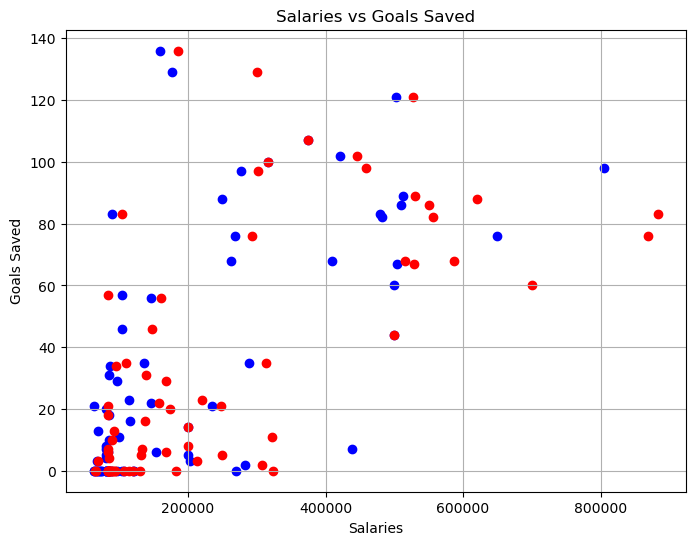

```python
# plot scatterplots for goalkeepers' salaries vs goals saved for both 2021 and 2022 salaries

plt.figure(figsize = (8, 6))
plt.scatter(goalkeepers_df['2021 guaranteed comp.'], goalkeepers_df['saves'], color = 'blue', label = '2021')
plt.scatter(goalkeepers_df['2022 guar. comp.'], goalkeepers_df['saves'], color = 'red', label = '2022')
plt.xlabel('Salaries')
plt.ylabel('Goals Saved')
plt.title('Salaries vs Goals Saved')
plt.grid(True)
plt.show()
```

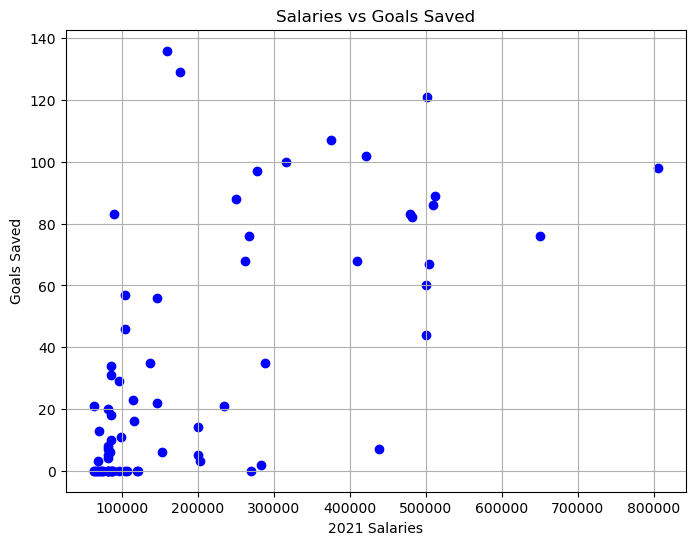

```python
# separate graph for just 2021 salaries vs goals saved by goalkeepers

plt.figure(figsize = (8, 6))
plt.scatter(goalkeepers_df['2021 guaranteed comp.'], goalkeepers_df['saves'], color = 'blue')
plt.xlabel('2021 Salaries')
plt.ylabel('Goals Saved')
plt.title('Salaries vs Goals Saved')
plt.grid(True)
plt.show()
```

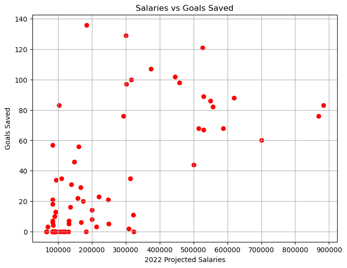

```python
# separate graph for just 2022 projected salaries vs goals saved by goalkeepers

plt.figure(figsize = (8, 6))
plt.scatter(goalkeepers_df['2022 guar. comp.'], goalkeepers_df['saves'], color = 'red')
plt.xlabel('2022 Projected Salaries')
plt.ylabel('Goals Saved')
plt.title('Salaries vs Goals Saved')
plt.grid(True)
plt.show()
```

Graphs 5-7: The analysis of goalkeeper salaries requires further refinement, given the multitude of metrics that can be employed to gauge performance beyond saves made. However, for the present investigation, we're focusing on salaries in relation to the number of saves made. Graph 5 depicts both the 2021 salaries and the projected 2022 salaries on a unified plot. While the graph indicates some salaries projected to rise in 2022, a detailed examination of the top 10 goalkeepers ranked by saves made reveals no definitive trend correlating these metrics. Surprisingly, there are instances where salaries are anticipated to remain constant, and in the case of Brad Guzan, one goalkeeper's projected salary for 2022 is lower. Similar to the previous analysis, Graph 6 isolates data exclusively for the 2021 season, while Graph 7 provides insights into projected salaries for the 2022 season.

```python
# create a dataframe that reflects just the midfields

midfielders_df = mls_dataset[mls_dataset['position'] == 'Midfielder']
midfielders_df
```

|  | name | club_abb | club | 2021 guaranteed comp. | 2022 guar. comp. | position | birth_city | birth_country | height, cm | weight, kg | ... | accurate_goal_kicks | dive_catch | inaccurate_goal_kicks | penalty_faced | pen_goals_conceded | punches | drops | good_claim | saves_per | goals_against_average |
| --- | --- | --- | --- | --- | --- | --- | --- | --- | --- | --- | --- | --- | --- | --- | --- | --- | --- | --- | --- | --- | --- |
| 4 | Damir Kreilach | RSL | Real Salt Lake | 1350000.0 | 1762572.0 | Midfielder | Vukovar | Croatia | 186.0 | 79.0 | ... | 0 | 0 | 0 | 0 | 3 | 0 | 0 | 0 | 0.0 | 1.50 |
| 5 | Hany Mukhtar | NSH | Nashville | 1505000.0 | 1926250.0 | Midfielder | Berlin | Germany | 173.0 | 72.0 | ... | 0 | 0 | 0 | 0 | 3 | 0 | 0 | 0 | 0.0 | 1.08 |
| 15 | Lucas Zelarayan | CLB | Columbus Crew | 1985000.0 | 3700000.0 | Midfielder | Córdoba | Argentina | 172.0 | 70.0 | ... | 0 | 0 | 0 | 0 | 4 | 0 | 0 | 0 | 0.0 | 1.37 |
| 17 | Fafa Picault | HOU | Houston Dynamo | 500000.0 | 600000.0 | Midfielder | New York | USA | 173.0 | 63.0 | ... | 0 | 0 | 0 | 0 | 4 | 0 | 0 | 0 | 0.0 | 1.53 |
| 18 | Albert Rusnak | RSL | Real Salt Lake | 2351667.0 | 1871667.0 | Midfielder | Vyškov | Czech Republic | 175.0 | 61.0 | ... | 0 | 0 | 0 | 0 | 3 | 0 | 0 | 0 | 0.0 | 1.60 |
| ... | ... | ... | ... | ... | ... | ... | ... | ... | ... | ... | ... | ... | ... | ... | ... | ... | ... | ... | ... | ... | ... |
| 597 | Victor Ulloa | MIA | Inter Miami | 220000.0 | 250000.0 | Midfielder | Wylie | USA | 181.0 | 75.0 | ... | 0 | 0 | 0 | 0 | 2 | 0 | 0 | 0 | 0.0 | 1.52 |
| 601 | Pedro Vite | VAN | Vancouver Whitecaps | 609997.0 | 609997.0 | Midfielder | Babahoyo | Ecuador | 168.0 | 68.0 | ... | 0 | 0 | 0 | 0 | 0 | 0 | 0 | 0 | NaN | NaN |
| 614 | Owen Wolff | ATX | Austin | 76600.0 | 78553.0 | Midfielder | Snellville | USA | 176.0 | 66.0 | ... | 0 | 0 | 0 | 0 | 0 | 0 | 0 | 0 | NaN | 0.00 |
| 619 | Gedion Zelalem | NYC | New York City | 81375.0 | 84000.0 | Midfielder | Berlin | Germany | 180.0 | 74.0 | ... | 0 | 0 | 0 | 0 | 0 | 0 | 0 | 0 | NaN | 0.00 |
| 620 | Rida Zouhir | MTL | Montreal | 71730.0 | 74809.0 | Midfielder | NaN | Canada | 178.0 | 73.0 | ... | 0 | 0 | 0 | 0 | 0 | 0 | 0 | 0 | NaN | 0.00 |

220 rows × 109 columns

```python
# sort by most assists

midfielders_df_sorted = midfielders_df.sort_values(by = 'assist', ascending = False)
midfielders_df_sorted.head(10)
```

|  | name | club_abb | club | 2021 guaranteed comp. | 2022 guar. comp. | position | birth_city | birth_country | height, cm | weight, kg | ... | accurate_goal_kicks | dive_catch | inaccurate_goal_kicks | penalty_faced | pen_goals_conceded | punches | drops | good_claim | saves_per | goals_against_average |
| --- | --- | --- | --- | --- | --- | --- | --- | --- | --- | --- | --- | --- | --- | --- | --- | --- | --- | --- | --- | --- | --- |
| 71 | Carles Gil | NE | New England Revolutio | 3045833.0 | 3545833.0 | Midfielder | Valencia | Spain | 171.0 | 65.0 | ... | 0 | 0 | 0 | 0 | 2 | 0 | 0 | 0 | 0.0 | 1.18 |
| 78 | Djordje Mihailovic | MTL | Montreal | 651875.0 | 751875.0 | Midfielder | Jacksonville, FL | USA | 178.0 | 69.0 | ... | 0 | 0 | 0 | 0 | 5 | 0 | 0 | 0 | 0.0 | 1.28 |
| 5 | Hany Mukhtar | NSH | Nashville | 1505000.0 | 1926250.0 | Midfielder | Berlin | Germany | 173.0 | 72.0 | ... | 0 | 0 | 0 | 0 | 3 | 0 | 0 | 0 | 0.0 | 1.08 |
| 527 | Jack Price | COL | Colorado Rapids | 655625.0 | 725000.0 | Midfielder | NaN | England | 170.0 | 87.0 | ... | 0 | 0 | 0 | 0 | 1 | 0 | 0 | 0 | 0.0 | 1.06 |
| 108 | Maxi Moralez | NYC | New York City | 3285000.0 | 1300000.0 | Midfielder | Granadero Baigorria | Argentina | 160.0 | 52.0 | ... | 0 | 0 | 0 | 0 | 2 | 0 | 0 | 0 | 0.0 | 1.02 |
| 18 | Albert Rusnak | RSL | Real Salt Lake | 2351667.0 | 1871667.0 | Midfielder | Vyškov | Czech Republic | 175.0 | 61.0 | ... | 0 | 0 | 0 | 0 | 3 | 0 | 0 | 0 | 0.0 | 1.60 |
| 60 | Emanuel Reynoso | MIN | Minnesota United | 966910.0 | 1066910.0 | Midfielder | Córdoba | Argentina | 177.0 | 65.0 | ... | 0 | 0 | 0 | 0 | 1 | 0 | 0 | 0 | 0.0 | 1.13 |
| 251 | Mauricio Pereyra | ORL | Orlando City | 1848000.0 | 1348000.0 | Midfielder | Montevideo | Uruguay | 170.0 | 63.0 | ... | 0 | 0 | 0 | 0 | 2 | 0 | 0 | 0 | 0.0 | 1.37 |
| 35 | Luciano Acosta | CIN | Cincinnati | 2222854.0 | 2222854.0 | Midfielder | Rosario | Argentina | 161.0 | 61.0 | ... | 0 | 0 | 0 | 0 | 2 | 0 | 0 | 0 | 0.0 | 2.04 |
| 4 | Damir Kreilach | RSL | Real Salt Lake | 1350000.0 | 1762572.0 | Midfielder | Vukovar | Croatia | 186.0 | 79.0 | ... | 0 | 0 | 0 | 0 | 3 | 0 | 0 | 0 | 0.0 | 1.50 |

10 rows × 109 columns

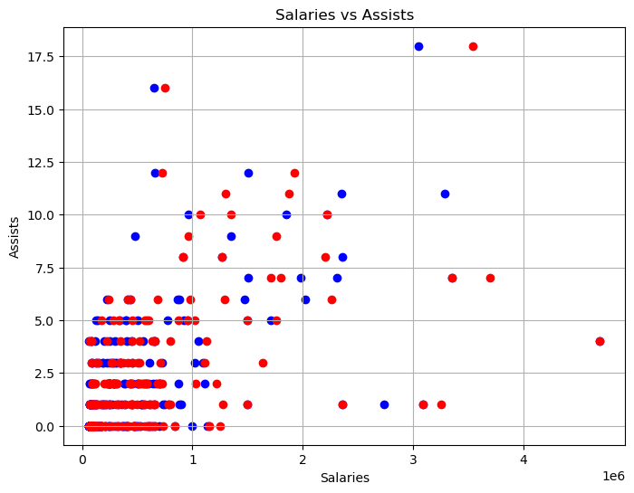

```python
# plot scatterplots for midfielders' salaries vs assists for both 2021 and 2022 salaries

plt.figure(figsize = (8, 6))
plt.scatter(midfielders_df['2021 guaranteed comp.'], midfielders_df['assist'], color = 'blue', label = '2021')
plt.scatter(midfielders_df['2022 guar. comp.'], midfielders_df['assist'], color = 'red', label = '2022')
plt.xlabel('Salaries')
plt.ylabel('Assists')
plt.title('Salaries vs Assists')
plt.grid(True)
plt.show()
```

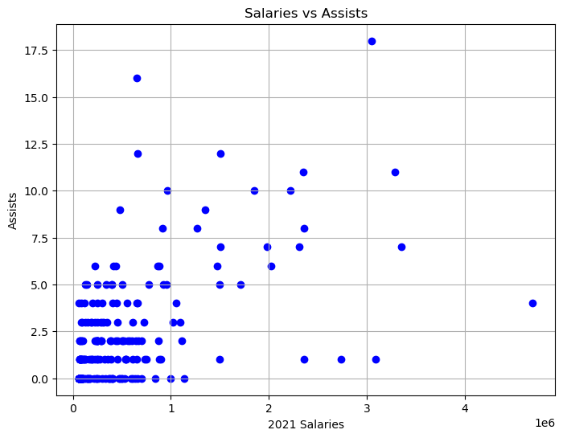

```python
# separate graph for just 2021 salaries vs goals saved by goalkeepers

plt.figure(figsize = (8, 6))
plt.scatter(midfielders_df['2021 guaranteed comp.'], midfielders_df['assist'], color = 'blue')
plt.xlabel('2021 Salaries')
plt.ylabel('Assists')
plt.title('Salaries vs Assists')
plt.grid(True)
plt.show()
```

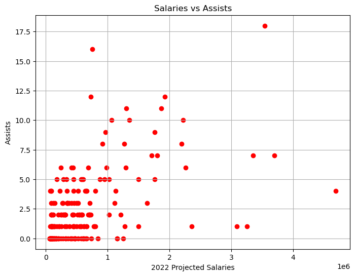

```python
# separate graph for just 2021 salaries vs goals saved by goalkeepers

plt.figure(figsize = (8, 6))
plt.scatter(midfielders_df['2022 guar. comp.'], midfielders_df['assist'], color = 'red')
plt.xlabel('2022 Projected Salaries')
plt.ylabel('Assists')
plt.title('Salaries vs Assists')
plt.grid(True)
plt.show()
```

Graphs 8-10: Similarly, the analysis for midfielders focuses solely on assists made for this study, though it's important to acknowledge the availability of other metrics that can be used to measure performance for this position. Graph 8 presents both the 2021 salaries and the projected 2022 salaries on a consolidated plot. While the graph highlights projected salary increases, the data also reveals three midfielders (Maxi Moralez, Albert Rusnak, and Mauricio Pereyra) anticipating a decrease in pay. Graph 9 isolates data exclusively for the 2021 season, while Graph 10 offers insights into projected salaries for the 2022 season.

```python
# create a dataframe that reflects just the defenders

defenders_df = mls_dataset[mls_dataset['position'] == 'Defender']
defenders_df
```

|  | name | club_abb | club | 2021 guaranteed comp. | 2022 guar. comp. | position | birth_city | birth_country | height, cm | weight, kg | ... | accurate_goal_kicks | dive_catch | inaccurate_goal_kicks | penalty_faced | pen_goals_conceded | punches | drops | good_claim | saves_per | goals_against_average |
| --- | --- | --- | --- | --- | --- | --- | --- | --- | --- | --- | --- | --- | --- | --- | --- | --- | --- | --- | --- | --- | --- |
| 75 | Mamadou Fall | LAFC | LAFC | 94125.0 | 118750.0 | Defender | Rufisque | Senegal | 188.0 | 74.0 | ... | 0 | 0 | 0 | 0 | 0 | 0 | 0 | 0 | 0.0 | 1.67 |
| 76 | Jimmy Medranda | SEA | Seattle Sounders | 190000.0 | 210000.0 | Defender | Mosquera | Colombia | 166.0 | 69.0 | ... | 0 | 0 | 0 | 0 | 0 | 0 | 0 | 0 | 0.0 | 0.83 |
| 93 | Rudy Camacho | MTL | Montreal | 851653.0 | 554000.0 | Defender | L'Arbresle | France | 185.0 | 79.0 | ... | 2 | 0 | 0 | 0 | 4 | 0 | 0 | 0 | 0.0 | 1.25 |
| 99 | Jon Gallagher | ATX | Austin | 81375.0 | 155000.0 | Defender | NaN | Ireland | 175.0 | 72.0 | ... | 0 | 0 | 0 | 0 | 1 | 0 | 0 | 0 | 0.0 | 1.57 |
| 100 | Jakob Glesnes | PHI | Philadelphia Union | 448125.0 | 739063.0 | Defender | Bergen | Norway | 188.0 | 84.0 | ... | 0 | 0 | 1 | 0 | 3 | 0 | 0 | 0 | 0.0 | 1.03 |
| ... | ... | ... | ... | ... | ... | ... | ... | ... | ... | ... | ... | ... | ... | ... | ... | ... | ... | ... | ... | ... | ... |
| 611 | Thomas Williams | ORL | Orlando City | 70077.0 | 73254.0 | Defender | NaN | USA | 191.0 | 77.0 | ... | 0 | 0 | 0 | 0 | 0 | 0 | 0 | 0 | NaN | NaN |
| 615 | Karifa Yao | MTL | Montreal | 85591.0 | 89933.0 | Defender | NaN | Canada | 191.0 | 85.0 | ... | 0 | 0 | 0 | 0 | 0 | 0 | 0 | 0 | NaN | NaN |
| 618 | Eriq Zavaleta | TOR | Toronto | 115503.0 | 84000.0 | Defender | Westfield | USA | 186.0 | 83.0 | ... | 0 | 0 | 0 | 0 | 3 | 0 | 0 | 0 | 0.0 | 2.21 |
| 621 | Dario Zuparic | POR | Portland Timbers | 541667.0 | 579200.0 | Defender | Zupanja | Croatia | 185.0 | 84.0 | ... | 0 | 0 | 0 | 0 | 6 | 0 | 0 | 0 | 0.0 | 1.50 |
| 622 | Graham Zusi | SKC | Sporting Kansas City | 713333.0 | 450000.0 | Defender | Longwood | USA | 178.0 | 72.0 | ... | 0 | 0 | 0 | 0 | 2 | 0 | 0 | 0 | 0.0 | 1.18 |

199 rows × 109 columns

```python
# sort by least goals conceded in box

defenders_df_sorted = defenders_df.sort_values(by = 'goals_conceded_ibox', ascending = True)
defenders_df_sorted.head(10)
```

|  | name | club_abb | club | 2021 guaranteed comp. | 2022 guar. comp. | position | birth_city | birth_country | height, cm | weight, kg | ... | accurate_goal_kicks | dive_catch | inaccurate_goal_kicks | penalty_faced | pen_goals_conceded | punches | drops | good_claim | saves_per | goals_against_average |
| --- | --- | --- | --- | --- | --- | --- | --- | --- | --- | --- | --- | --- | --- | --- | --- | --- | --- | --- | --- | --- | --- |
| 574 | Anthony Sorenson | PHI | Philadelphia Union | 66547.0 | 88444.0 | Defender | Port-au-Prince | Haiti | 168.0 | 57.0 | ... | 0 | 0 | 0 | 0 | 0 | 0 | 0 | 0 | NaN | NaN |
| 379 | Kortne Ford | COL | Colorado Rapids | 140000.0 | 151667.0 | Defender | Olathe | USA | 188.0 | 84.0 | ... | 0 | 0 | 0 | 0 | 0 | 0 | 0 | 0 | NaN | NaN |
| 376 | Marcus Ferkranus | LA | LA Galaxy | 103625.0 | 113625.0 | Defender | Santa Clarita, CA | USA | 185.0 | 84.0 | ... | 0 | 0 | 0 | 0 | 0 | 0 | 0 | 0 | NaN | NaN |
| 375 | Keesean Ferdinand | MTL | Montreal | 73592.0 | 99936.0 | Defender | Rivière-des-Prairies | Canada | 183.0 | 72.0 | ... | 0 | 0 | 0 | 0 | 0 | 0 | 0 | 0 | NaN | NaN |
| 473 | Christian Mcfarlane | NYC | New York City | 81803.0 | 83756.0 | Defender | NaN | England | 182.0 | 63.0 | ... | 0 | 0 | 0 | 0 | 0 | 0 | 0 | 0 | NaN | NaN |
| 584 | Ben Sweat | ATX | Austin | 250000.0 | 200000.0 | Defender | Palm Harbor | USA | 185.0 | 80.0 | ... | 0 | 0 | 0 | 0 | 0 | 0 | 0 | 0 | 0.0 | 0.97 |
| 373 | Zackery Farnsworth | RSL | Real Salt Lake | 96125.0 | 98750.0 | Defender | Cedar Hills | USA | 185.0 | 75.0 | ... | 0 | 0 | 0 | 0 | 0 | 0 | 0 | 0 | NaN | NaN |
| 368 | Franco Escobar | ATL | Atlanta United | 450000.0 | 550008.0 | Defender | Rosario | Argentina | 171.0 | 72.0 | ... | 0 | 0 | 0 | 0 | 0 | 0 | 0 | 0 | NaN | NaN |
| 362 | Michael Edwards | COL | Colorado Rapids | 81375.0 | 84000.0 | Defender | NaN | USA | 192.0 | 80.0 | ... | 0 | 0 | 0 | 0 | 0 | 0 | 0 | 0 | NaN | NaN |
| 573 | Collin Smith | DAL | Dallas | 66547.0 | 93000.0 | Defender | Jacksonville | USA | 178.0 | 78.0 | ... | 0 | 0 | 0 | 0 | 0 | 0 | 0 | 0 | NaN | NaN |

10 rows × 109 columns

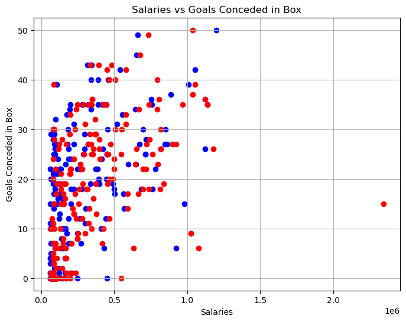

```python
# plot scatterplots for defenders' salaries vs goals conceded in box for both 2021 and 2022 salaries

plt.figure(figsize = (8, 6))
plt.scatter(defenders_df['2021 guaranteed comp.'], defenders_df['goals_conceded_ibox'], color = 'blue', label = '2021')
plt.scatter(defenders_df['2022 guar. comp.'], defenders_df['goals_conceded_ibox'], color = 'red', label = '2022')
plt.xlabel('Salaries')
plt.ylabel('Goals Conceded in Box')
plt.title('Salaries vs Goals Conceded in Box')
plt.grid(True)
plt.show()
```

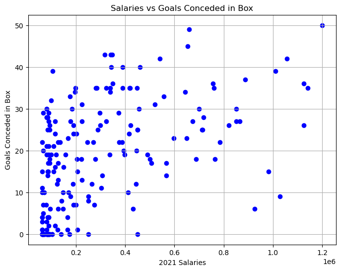

```python
# separate graph for just 2021 salaries vs goals conceded in box by defenders

plt.figure(figsize = (8, 6))
plt.scatter(defenders_df['2021 guaranteed comp.'], defenders_df['goals_conceded_ibox'], color = 'blue')
plt.xlabel('2021 Salaries')
plt.ylabel('Goals Conceded in Box')
plt.title('Salaries vs Goals Conceded in Box')
plt.grid(True)
plt.show()
```

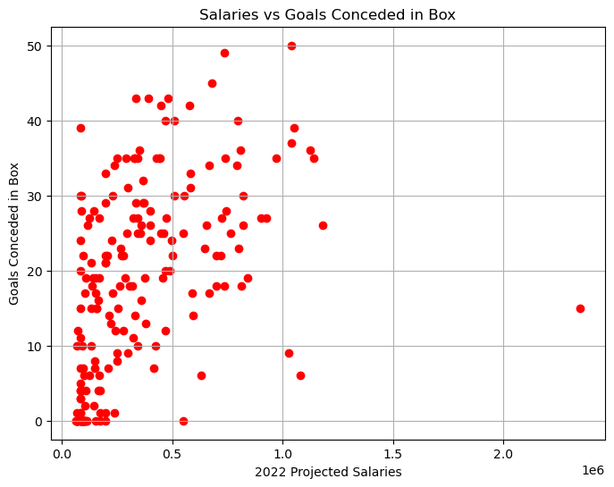

```python
plt.figure(figsize = (8, 6))
plt.scatter(defenders_df['2022 guar. comp.'], defenders_df['goals_conceded_ibox'], color = 'red')
plt.xlabel('2022 Projected Salaries')
plt.ylabel('Goals Conceded in Box')
plt.title('Salaries vs Goals Conceded in Box')
plt.grid(True)
plt.show()
```

Conclusion: Based on the insights gleaned from the graphical analysis of the selected performance metrics, a direct correlation between performance and salary increases in Major League Soccer (MLS) does not seem evident. It appears that individual players' salary adjustments are influenced by factors beyond performance alone, potentially including factors such as popularity or marketability. While there are instances where performance does appear to impact salary adjustments, it does not appear to be the sole determining factor, as anticipated. Further in-depth analysis is necessary to explore whether other performance metrics may offer better correlation, if any, and to investigate the allocation of resources by a particular team concerning player salaries and performance.

*Milestone 2: Data Preparation*

**Rename Headers.**

```python
# rename the columns to make it more clean
mls_dataset.rename(columns = {"name": "Name", "club_abb": "Club Abbreviation", "club": "Club",
                            "2021 guaranteed comp.": "2021 Guaranteed Compensation", "2022 guar. comp.": "2022 Guaranteed Compensation",
                            "position": "Position", "birth_city": "Birth City", "birth_country": "Birth Country", "height, cm": "Height in Centimeters",
                            "weight, kg": "Weight in Kilograms", "foot": "Foot",
                            "games_played": "Games Played", "game_started": "Games Started",
                            "mins": "Minutes Played", "sub_on": "Sub On", "total_sub_off": "Total Sub Off",
                            "total_wins": "Total Wins", "total_losses": "Total Losses",
                            "total_draws": "Total Draws", "goals": "Goals", "goal_conversion_per": "Goal Conversion Per Game", "assist": "Assist",
                            "accurate_back_zone_pass": "Accurate Back Zone Pass", "failed_back_zone_pass": "Failed Back Zone Pass",
                            "accurate_cross": "Accurate Cross", "failed_cross": "Failed Cross",
                            "accurate_cross_per": "Accurate Cross Per Game", "accurate_cross_nocorner": "Accurate Cross No Corner", "failed_cross_nocorner": "Failed Cross No Corner",
                            "accurate_fwd_zone_pass": "Accurate Forward Zone Pass", "failed_fwd_zone_pass": "Failed Forward Zone Pass",
                            "accurate_fwd_zone_pass_per": "Accurate Forward Zone Pass Per Game", "accurate_launches": "Accurate Launches", "failed_launches": "Failed Launches", "accurate_layoffs": "Accurate Layoffs",
                            "failed_layoffs": "Failed Layoffs", "accurate_long_balls": "Accurate Long Balls",
                            "failed_long_balls": "Failed Long Balls", "accurate_pass": "Accurate Pass",
                            "accurate_pass_per": "Accurate Pass Per Game", "accurate_throws": "Accurate Throws", "failed_throws": "Failed Throws",
                            "aerial_lost": "Aerial Lost", "aerial_won": "Aerial Won",
                            "head_goal": "Head Goal", "inside_box_goal": "Inside Box Goal", "outside_box_goal": "Outside Box Goal", "left_foot_goal": "Left Foot Goal",
                            "right_foot_goal": "Right Foot Goal", "penalty_goal": "Penalty Goal",
                            "attempted_tackle_foul": "Attempted Tackle Foul", "fwd_pass": "Forward Pass",
                            "back_pass": "Back Pass", "ball_recovery": "Ball Recovery",
                            "successful_dribble": "Successful Dribble", "failed_dribble": "Failed Dribble", "successful_short_pass": "Successful Short Pass", "failed_short_pass": "Failed Short Pass",
                            "fk_foul_lost": "Free Kick Foul Lost", "fk_foul_won": "Free Kick Foul Won",
                            "ground_duel_lost": "Ground Duel Lost", "ground_duel_won": "Ground Duel Won",
                            "hand_ball": "Hand Ball", "won_tackle": "Won Tackle", "lost_tackle": "Lost Tackle",
                            "total_tackle": "Total Tackle", "tackle_success_per": "Tackle Success Per Game",
                            "ontarget_scoring_att": "Shots on Target", "total_scoring_att": "Total Shots at Goal", "accurate_shooting_per": "Accurate Shooting Per Game", "successful_open_play_pass": "Successful Open Play Pass",
                            "outfielder_block": "Outfielder Block", "pen_taken": "Penalty Taken",
                            "penalty_won": "Penalty Won", "poss_lost_all": "Possession Lost",
                            "total_clearance": "Total Clearance", "total_offside": "Total Offside", "total_pass": "Total Pass",
                            "total_pass_miss": "Total Passes Missed", "total_through_ball": "Total Through Ball",
                            "touches": "Touches", "won_corners": "Corners Won", "fifty_fifty": "Fifty Fifty", "successful_fifty_fifty": "Successful Fifty Fifty",
                            "yellow_card": "Yellow Card", "duel": "Duel",
                            "duel_lost": "Duel Lost", "duel_won": "Duel Won",
                            "aerial_duel": "Aerial Duel", "ground_duel": "Ground Duel",
                            "times_tackled": "Times Tackled", "interception": "Interception", "goals_conceded": "Goals Conceded",
                            "goals_conceded_ibox": "Goals Conceded In Box", "goals_conceded_obox": "Goals Conceded Out of Box",
                            "saves": "Saves", "saved_ibox": "Saved In Box", "saved_obox": "Saved Out of Box", "clean_sheet": "Clean Sheet",
                            "accurate_goal_kicks": "Accurate Goal Kicks", "dive_catch": "Dive Catch",
                            "inaccurate_goal_kicks": "Innacurate Goal Kicks", "penalty_faced": "Penalty Faced",
                            "pen_goals_conceded": "Penalty Goals Conceded", "punches": "Punches", "drops": "Drops", "good_claim": "Good Claim",
                            "saves_per": "Saves Per Game", "goals_against_average": "Goals Against Average"}, inplace = True)
```

```python
# check new column headers
mls_dataset.head()
```

|  | Name | Club Abbreviation | Club | 2021 Guaranteed Compensation | 2022 Guaranteed Compensation | Position | Birth City | Birth Country | Height in Centimeters | Weight in Kilograms | ... | Accurate Goal Kicks | Dive Catch | Innacurate Goal Kicks | Penalty Faced | Penalty Goals Conceded | Punches | Drops | Good Claim | Saves Per Game | Goals Against Average |
| --- | --- | --- | --- | --- | --- | --- | --- | --- | --- | --- | --- | --- | --- | --- | --- | --- | --- | --- | --- | --- | --- |
| 0 | Valentin Castellanos | NYC | New York City | 776000.0 | 1076000.0 | Forward | Mendoza | Argentina | 178.0 | 70.0 | ... | 0 | 0 | 0 | 0 | 3 | 0 | 0 | 0 | 0.0 | 0.95 |
| 1 | Ola Kamara | DC | DC United | 420000.0 | 1520000.0 | Forward | NaN | Norway | 185.0 | 82.0 | ... | 0 | 0 | 0 | 0 | 2 | 0 | 0 | 0 | 0.0 | 1.43 |
| 2 | Javier Hernandez | LA | LA Galaxy | 6000000.0 | 7443750.0 | Forward | Guadalajara | Mexico | 175.0 | 73.0 | ... | 0 | 0 | 0 | 0 | 3 | 0 | 0 | 0 | 0.0 | 1.40 |
| 3 | Raul Ruidiaz | SEA | Seattle Sounders | 2100000.0 | 3201120.0 | Forward | Lima | Peru | 169.0 | 65.0 | ... | 0 | 0 | 0 | 0 | 3 | 0 | 0 | 0 | 0.0 | 0.92 |
| 4 | Damir Kreilach | RSL | Real Salt Lake | 1350000.0 | 1762572.0 | Midfielder | Vukovar | Croatia | 186.0 | 79.0 | ... | 0 | 0 | 0 | 0 | 3 | 0 | 0 | 0 | 0.0 | 1.50 |

5 rows × 109 columns

**Replace White Spaces in Column Names with an Underscore.**

```python
# use snake_case instead of whitespace for column names to increase readability and compatibility
mls_dataset.columns = mls_dataset.columns.str.replace(' ','_')
mls_dataset.head()
```

|  | Name | Club_Abbreviation | Club | 2021_Guaranteed_Compensation | 2022_Guaranteed_Compensation | Position | Birth_City | Birth_Country | Height_in_Centimeters | Weight_in_Kilograms | ... | Accurate_Goal_Kicks | Dive_Catch | Innacurate_Goal_Kicks | Penalty_Faced | Penalty_Goals_Conceded | Punches | Drops | Good_Claim | Saves_Per_Game | Goals_Against_Average |
| --- | --- | --- | --- | --- | --- | --- | --- | --- | --- | --- | --- | --- | --- | --- | --- | --- | --- | --- | --- | --- | --- |
| 0 | Valentin Castellanos | NYC | New York City | 776000.0 | 1076000.0 | Forward | Mendoza | Argentina | 178.0 | 70.0 | ... | 0 | 0 | 0 | 0 | 3 | 0 | 0 | 0 | 0.0 | 0.95 |
| 1 | Ola Kamara | DC | DC United | 420000.0 | 1520000.0 | Forward | NaN | Norway | 185.0 | 82.0 | ... | 0 | 0 | 0 | 0 | 2 | 0 | 0 | 0 | 0.0 | 1.43 |
| 2 | Javier Hernandez | LA | LA Galaxy | 6000000.0 | 7443750.0 | Forward | Guadalajara | Mexico | 175.0 | 73.0 | ... | 0 | 0 | 0 | 0 | 3 | 0 | 0 | 0 | 0.0 | 1.40 |
| 3 | Raul Ruidiaz | SEA | Seattle Sounders | 2100000.0 | 3201120.0 | Forward | Lima | Peru | 169.0 | 65.0 | ... | 0 | 0 | 0 | 0 | 3 | 0 | 0 | 0 | 0.0 | 0.92 |
| 4 | Damir Kreilach | RSL | Real Salt Lake | 1350000.0 | 1762572.0 | Midfielder | Vukovar | Croatia | 186.0 | 79.0 | ... | 0 | 0 | 0 | 0 | 3 | 0 | 0 | 0 | 0.0 | 1.50 |

5 rows × 109 columns

**Drop any features that are not useful for your model building and explain why they are not useful.**

```python
mls_dataset.drop(columns = ['Club_Abbreviation', 'Birth_City', 'Foot'], inplace = True)
mls_dataset.head()
```

|  | Name | Club | 2021_Guaranteed_Compensation | 2022_Guaranteed_Compensation | Position | Birth_Country | Height_in_Centimeters | Weight_in_Kilograms | Games_Played | Games_Started | ... | Accurate_Goal_Kicks | Dive_Catch | Innacurate_Goal_Kicks | Penalty_Faced | Penalty_Goals_Conceded | Punches | Drops | Good_Claim | Saves_Per_Game | Goals_Against_Average |
| --- | --- | --- | --- | --- | --- | --- | --- | --- | --- | --- | --- | --- | --- | --- | --- | --- | --- | --- | --- | --- | --- |
| 0 | Valentin Castellanos | New York City | 776000.0 | 1076000.0 | Forward | Argentina | 178.0 | 70.0 | 32 | 32 | ... | 0 | 0 | 0 | 0 | 3 | 0 | 0 | 0 | 0.0 | 0.95 |
| 1 | Ola Kamara | DC United | 420000.0 | 1520000.0 | Forward | Norway | 185.0 | 82.0 | 28 | 22 | ... | 0 | 0 | 0 | 0 | 2 | 0 | 0 | 0 | 0.0 | 1.43 |
| 2 | Javier Hernandez | LA Galaxy | 6000000.0 | 7443750.0 | Forward | Mexico | 175.0 | 73.0 | 21 | 20 | ... | 0 | 0 | 0 | 0 | 3 | 0 | 0 | 0 | 0.0 | 1.40 |
| 3 | Raul Ruidiaz | Seattle Sounders | 2100000.0 | 3201120.0 | Forward | Peru | 169.0 | 65.0 | 26 | 24 | ... | 0 | 0 | 0 | 0 | 3 | 0 | 0 | 0 | 0.0 | 0.92 |
| 4 | Damir Kreilach | Real Salt Lake | 1350000.0 | 1762572.0 | Midfielder | Croatia | 186.0 | 79.0 | 33 | 32 | ... | 0 | 0 | 0 | 0 | 3 | 0 | 0 | 0 | 0.0 | 1.50 |

5 rows × 106 columns

Three features were removed from the dataset because they did not contribute significantly to model building.

The first feature, "club_abb" (club abbreviation), was redundant as we already had another column indicating the player's club affiliation.

The second feature, "birth_city," was dropped because the specific city of birth did not provide valuable information for the model. However, we decided to retain the "birth_country" feature as it may be relevant for analyzing international stardom and its impact on salary increases.

Lastly, the "foot" feature was eliminated since whether a player is right or left-footed was not found to be a determining factor in salary fluctuations, which is the focus of our analysis.

**Perform any data extraction/selection steps.**

```python
# feature selection
selected_features = mls_dataset.corr(numeric_only = True)['2022_Guaranteed_Compensation'].abs().nlargest(10).index
selected_features
```

```
Index(['2022_Guaranteed_Compensation', '2021_Guaranteed_Compensation',
       'Shots_on_Target', 'Total_Shots_at_Goal', 'Goals', 'Accurate_Layoffs',
       'Inside_Box_Goal', 'Right_Foot_Goal', 'Total_Through_Ball',
       'Free_Kick_Foul_Won'],
      dtype='object')
```

'selected_features' will contain the names of the 10 features (columns) from mls_dataset that have the highest absolute correlation values with the column '2022 guar. comp.'.

**Engineer new useful features.**

```python
# calculate bmi from players weight and height
mls_dataset['BMI'] = mls_dataset['Weight_in_Kilograms'] / ((mls_dataset['Height_in_Centimeters'] / 100) ** 2)
mls_dataset.head()
```

|  | Name | Club | 2021_Guaranteed_Compensation | 2022_Guaranteed_Compensation | Position | Birth_Country | Height_in_Centimeters | Weight_in_Kilograms | Games_Played | Games_Started | ... | Dive_Catch | Innacurate_Goal_Kicks | Penalty_Faced | Penalty_Goals_Conceded | Punches | Drops | Good_Claim | Saves_Per_Game | Goals_Against_Average | BMI |
| --- | --- | --- | --- | --- | --- | --- | --- | --- | --- | --- | --- | --- | --- | --- | --- | --- | --- | --- | --- | --- | --- |
| 0 | Valentin Castellanos | New York City | 776000.0 | 1076000.0 | Forward | Argentina | 178.0 | 70.0 | 32 | 32 | ... | 0 | 0 | 0 | 3 | 0 | 0 | 0 | 0.0 | 0.95 | 22.093170 |
| 1 | Ola Kamara | DC United | 420000.0 | 1520000.0 | Forward | Norway | 185.0 | 82.0 | 28 | 22 | ... | 0 | 0 | 0 | 2 | 0 | 0 | 0 | 0.0 | 1.43 | 23.959094 |
| 2 | Javier Hernandez | LA Galaxy | 6000000.0 | 7443750.0 | Forward | Mexico | 175.0 | 73.0 | 21 | 20 | ... | 0 | 0 | 0 | 3 | 0 | 0 | 0 | 0.0 | 1.40 | 23.836735 |
| 3 | Raul Ruidiaz | Seattle Sounders | 2100000.0 | 3201120.0 | Forward | Peru | 169.0 | 65.0 | 26 | 24 | ... | 0 | 0 | 0 | 3 | 0 | 0 | 0 | 0.0 | 0.92 | 22.758307 |
| 4 | Damir Kreilach | Real Salt Lake | 1350000.0 | 1762572.0 | Midfielder | Croatia | 186.0 | 79.0 | 33 | 32 | ... | 0 | 0 | 0 | 3 | 0 | 0 | 0 | 0.0 | 1.50 | 22.835010 |

5 rows × 107 columns

BMI can be used as a general indicator of physical fitness and body composition for soccer players. Players with a healthy BMI are more likely to have optimal muscle mass and body fat levels, which are important for performance on the field. While BMI alone does not determine soccer performance, it can be one of many factors considered in player evaluation and performance optimization. Players with a healthy BMI are more likely to have the stamina, endurance, and physical resilience needed to perform at their best during training and matches.

**Deal with missing data (do not just drop rows or columns without justifying this).**

```python
# check for missing values in each column
missing_counts = mls_dataset.isna().sum()

# identify columns with missing values
columns_with_missing = missing_counts[missing_counts > 0].index

# display columns with missing values
print("Columns with missing values:")
print(columns_with_missing)
```

```
Columns with missing values:
Index(['Height_in_Centimeters', 'Weight_in_Kilograms', 'Saves_Per_Game',
       'Goals_Against_Average', 'BMI'],
      dtype='object')
```

```python
# mls_dataset.fillna("Unknown", inplace = True)
# mls_dataset.head()
```

```python
# replace NaN values with the mean of each column
mls_dataset.fillna(mls_dataset.mean(numeric_only = True), inplace = True)
```

```python
mls_dataset.isna().sum()
```

```
Name                            0
Club                            0
2021_Guaranteed_Compensation    0
2022_Guaranteed_Compensation    0
Position                        0
                               ..
Drops                           0
Good_Claim                      0
Saves_Per_Game                  0
Goals_Against_Average           0
BMI                             0
Length: 107, dtype: int64
```

**Make dummies for categorical features.**

```python
categorical_features = ["Name", "Club", "Position", "Birth_Country"]
mls_dummies = pd.get_dummies(mls_dataset, columns = categorical_features)
mls_dummies.head()
```

|  | 2021_Guaranteed_Compensation | 2022_Guaranteed_Compensation | Height_in_Centimeters | Weight_in_Kilograms | Games_Played | Games_Started | Minutes_Played | Sub_On | Total_Sub_Off | Total_Wins | ... | Birth_Country_Switzerland | Birth_Country_Tanzania | Birth_Country_The Gambia | Birth_Country_Trinidad and Tobago | Birth_Country_USA | Birth_Country_Uganda | Birth_Country_Uruguay | Birth_Country_Uzbekistan | Birth_Country_Venezuela | Birth_Country_Zimbabwe |
| --- | --- | --- | --- | --- | --- | --- | --- | --- | --- | --- | --- | --- | --- | --- | --- | --- | --- | --- | --- | --- | --- |
| 0 | 776000.0 | 1076000.0 | 178.0 | 70.0 | 32 | 32 | 2760 | 0 | 12 | 14 | ... | False | False | False | False | False | False | False | False | False | False |
| 1 | 420000.0 | 1520000.0 | 185.0 | 82.0 | 28 | 22 | 1819 | 6 | 14 | 13 | ... | False | False | False | False | False | False | False | False | False | False |
| 2 | 6000000.0 | 7443750.0 | 175.0 | 73.0 | 21 | 20 | 1736 | 1 | 7 | 9 | ... | False | False | False | False | False | False | False | False | False | False |
| 3 | 2100000.0 | 3201120.0 | 169.0 | 65.0 | 26 | 24 | 2146 | 2 | 4 | 14 | ... | False | False | False | False | False | False | False | False | False | False |
| 4 | 1350000.0 | 1762572.0 | 186.0 | 79.0 | 33 | 32 | 2875 | 1 | 3 | 14 | ... | False | False | False | False | False | False | False | False | False | False |

5 rows × 827 columns

```python
mls_dummies.tail()
```

|  | 2021_Guaranteed_Compensation | 2022_Guaranteed_Compensation | Height_in_Centimeters | Weight_in_Kilograms | Games_Played | Games_Started | Minutes_Played | Sub_On | Total_Sub_Off | Total_Wins | ... | Birth_Country_Switzerland | Birth_Country_Tanzania | Birth_Country_The Gambia | Birth_Country_Trinidad and Tobago | Birth_Country_USA | Birth_Country_Uganda | Birth_Country_Uruguay | Birth_Country_Uzbekistan | Birth_Country_Venezuela | Birth_Country_Zimbabwe |
| --- | --- | --- | --- | --- | --- | --- | --- | --- | --- | --- | --- | --- | --- | --- | --- | --- | --- | --- | --- | --- | --- |
| 618 | 115503.0 | 84000.0 | 186.0 | 83.0 | 14 | 12 | 1020 | 2 | 3 | 1 | ... | False | False | False | False | True | False | False | False | False | False |
| 619 | 81375.0 | 84000.0 | 180.0 | 74.0 | 7 | 1 | 100 | 6 | 0 | 3 | ... | False | False | False | False | False | False | False | False | False | False |
| 620 | 71730.0 | 74809.0 | 178.0 | 73.0 | 2 | 0 | 16 | 2 | 0 | 1 | ... | False | False | False | False | False | False | False | False | False | False |
| 621 | 541667.0 | 579200.0 | 185.0 | 84.0 | 31 | 30 | 2700 | 1 | 1 | 16 | ... | False | False | False | False | False | False | False | False | False | False |
| 622 | 713333.0 | 450000.0 | 178.0 | 72.0 | 26 | 24 | 2129 | 2 | 3 | 13 | ... | False | False | False | False | True | False | False | False | False | False |

5 rows × 827 columns

*Milestone 3: Model Building and Evaluation.*

**Step 1: Split data into train and test sets.**

```python
from sklearn.model_selection import train_test_split
```

```python
# select target variable: "2022_Guaranteed_Compensation"
target_column = '2022_Guaranteed_Compensation'  # define target variable
y = mls_dummies[target_column]  # target variable
X = mls_dummies.drop(columns = [target_column])  # feature variables
```

```python
# split into train and test using 20% of the data for testing, and 80% for training
X_train, X_test, y_train, y_test = train_test_split(X, y, test_size = 0.2, random_state = 42)

# print the shapes of the resulting datasets
print("X_train shape:", X_train.shape)
print("X_test shape:", X_test.shape)
print("y_train shape:", y_train.shape)
print("y_test shape:", y_test.shape)
```

```
X_train shape: (498, 826)
X_test shape: (125, 826)
y_train shape: (498,)
y_test shape: (125,)
```

```python
# check the number of cells with "Unknown" value in the dataframe
unknown_count = (mls_dummies == "Unknown").sum().sum()

print("Number of cells with 'Unknown' value:", unknown_count)
```

```
Number of cells with 'Unknown' value: 0
```

**Step 2: Create a Correlation Matrix.**

```python
## create a correlation matrix
correlation_matrix = X_train.corr(numeric_only = True)
```

```python
# calculate the absolute correlations between all pairs of features in the training data
mls_correlations = X_train.corr(numeric_only = True).abs().stack().reset_index().sort_values(0, ascending = False)

# create a new column named "pairs" containing tuples of the variable names
mls_correlations['pairs'] = list(zip(mls_correlations.level_0, mls_correlations.level_1))

# set the index of the dataframe to the pairs column
mls_correlations.set_index(['pairs'], inplace = True)

# rename the correlation column to "correlation"
mls_correlations.rename(columns ={0: "correlation"}, inplace = True)

# drop pairs where both variables are the same (correlation of 1 indicates a variable correlated with itself)
mls_correlations.drop(mls_correlations[mls_correlations['correlation'] == 1.000000].index, inplace = True)

# view pairs with correlations above 75% and below 95%
mls_correlations[(mls_correlations.correlation > .75) & (mls_correlations.correlation < .95)]
```

| pairs | level_0 | level_1 | correlation |
| --- | --- | --- | --- |
| (Ground_Duel, Duel_Lost) | Ground_Duel | Duel_Lost | 0.949012 |
| (Duel_Lost, Ground_Duel) | Duel_Lost | Ground_Duel | 0.949012 |
| (Saves, Good_Claim) | Saves | Good_Claim | 0.947999 |
| (Good_Claim, Saves) | Good_Claim | Saves | 0.947999 |
| (Accurate_Goal_Kicks, Good_Claim) | Accurate_Goal_Kicks | Good_Claim | 0.946048 |
| ... | ... | ... | ... |
| (Interception, Outfielder_Block) | Interception | Outfielder_Block | 0.750469 |
| (Times_Tackled, Possession_Lost) | Times_Tackled | Possession_Lost | 0.750250 |
| (Possession_Lost, Times_Tackled) | Possession_Lost | Times_Tackled | 0.750250 |
| (Total_Shots_at_Goal, Ground_Duel_Lost) | Total_Shots_at_Goal | Ground_Duel_Lost | 0.750240 |
| (Ground_Duel_Lost, Total_Shots_at_Goal) | Ground_Duel_Lost | Total_Shots_at_Goal | 0.750240 |

898 rows × 3 columns

```python
# filter the correlation dataframe to include only correlations involving the target variable '2022_Guaranteed_Compensation'
# and sort them in descending order based on correlation values
mls_correlations = X_train.corr(numeric_only = True).abs().stack().reset_index().sort_values(0, ascending = False)
mls_correlations.loc[mls_correlations['level_0'] == '2022_Guaranteed_Compensation'].sort_values(0, ascending = False)
```

|  | level_0 | level_1 | 0 |
| --- | --- | --- | --- |

**Step 3: Build Models.**

*Linear Regression Model.*

```python
#import needed libraries
import pandas as pd
from sklearn.linear_model import LinearRegression
from sklearn.metrics import mean_squared_error, r2_score


# initialize the model
model = LinearRegression()

# train the model
model.fit(X_train, y_train)

# make predictions
y_pred_train = model.predict(X_train)
y_pred_test = model.predict(X_test)

# evaluate the model

# training set evaluation
mse_train = mean_squared_error(y_train, y_pred_train)
r2_train = r2_score(y_train, y_pred_train)
print(f"Training set - Mean Squared Error: {mse_train}")
print(f"Training set - R^2 Score: {r2_train}")

# testing set evaluation
mse_test = mean_squared_error(y_test, y_pred_test)
r2_test = r2_score(y_test, y_pred_test)
print(f"Testing set - Mean Squared Error: {mse_test}")
print(f"Testing set - R^2 Score: {r2_test}")
```

```
Training set - Mean Squared Error: 1.6429678971300458e-10
Training set - R^2 Score: 1.0
Testing set - Mean Squared Error: 113140582109.82799
Testing set - R^2 Score: 0.8858145875357414
```

**Evaluation:**

**Training Set Results:**

- Mean Squared Error: `1.6429678971300458e-10` which is extremely close to zero. This indicates that the model fits the training data almost perfectly.
- R² Score: `1.0` which is the maximum possible value, indicating a perfect fit.

**Testing Set Results:**

- Mean Squared Error: `113140582109.82799` which is significantly large. This indicates that the model's predictions on the testing set have substantial errors.
- R² Score: `0.8858145875357414` which is quite high, suggesting that the model explains a good portion of the variance in the testing data, but not as perfectly as it does in the training data.

**Conclusion:** The perfect scores on the training set (MSE close to zero and R² = 1.0) suggest that the model fits the training data extremely well. However, this might indicate overfitting, where the model has learned the training data too well, including its noise and outliers. The discrepancy between the training set and testing set results (particularly the high MSE on the testing set) further supports the possibility of overfitting. Although the R² score on the testing set is still high, the large MSE indicates that the model's predictions are not as accurate for unseen data.

*Decision Tree Regressor.*

```python
from sklearn.tree import DecisionTreeRegressor

# initialize decision tree regressor
decision_tree_model = DecisionTreeRegressor()

# train decision tree regressor
decision_tree_model.fit(X_train, y_train)

# make predictions
y_pred = decision_tree_model.predict(X_test)

# evaluate model
mse_tree = mean_squared_error(y_test, y_pred)
r2_tree = r2_score(y_test, y_pred)
print("Mean Squared Error:", mse_tree)
print("R^2 Score:", r2_tree)
```

```
Mean Squared Error: 333710816178.544
R^2 Score: 0.6632074320411205
```

**Evaluation:**

**Mean Squared Error:**

- Value: `333710816178.544`
- This is a large value, indicating that the model's predictions have substantial errors when compared to the actual values in the testing set. A high MSE suggests that the model's performance is not very accurate.

**R² Score:**

- Value: `0.6632074320411205`
- This indicates that approximately 66.32% of the variance in the dependent variable (2022_Guaranteed_Compensation) is explained by the model. While this is a reasonable proportion, it also indicates that around 33.68% of the variance is not explained by the model.

**Conclusion:** The decision tree model shows moderate performance, explaining about 66% of the variance in the target variable but with a relatively high mean squared error. The results suggest that the model is somewhat effective but may benefit from improvements.

*Random Forest Regressor.*

```python
from sklearn.ensemble import RandomForestRegressor

# initialize random forest regressor
random_forest_model = RandomForestRegressor()

# train random forest regressor
random_forest_model.fit(X_train, y_train)

# make predictions
y_pred = random_forest_model.predict(X_test)

# evaluate model
mse_random = mean_squared_error(y_test, y_pred)
r2_random = r2_score(y_test, y_pred)
print("Mean Squared Error:", mse_random)
print("R^2 Score:", r2_random)
```

```
Mean Squared Error: 228301915168.71487
R^2 Score: 0.7695897628967969
```

**Evaluation:**

**Mean Squared Error (MSE):**

- Value: `228301915168.71487`
- This is a large value, indicating that the model's predictions have significant errors when compared to the actual values in the testing set. A high MSE suggests that the model's performance has room for improvement.

**R² Score:**

- Value: `0.7695897628967969`
- This indicates that approximately 76.96% of the variance in the dependent variable (2022_Guaranteed_Compensation) is explained by the model. This is a good proportion, suggesting that the model captures the underlying patterns in the data fairly well.

**Conclusion:** The random forest model shows reasonable performance, explaining about 77% of the variance in the target variable, but with a relatively high mean squared error. The results suggest that the model is effective but may still benefit from improvements.

*Lasso Regression.*

```python
import pandas as pd
from sklearn.linear_model import Lasso
from sklearn.linear_model import LassoCV
# LassoCV will perform cross-validation to find the best alpha
lasso_cv_model = LassoCV(alphas = None, cv = 10, max_iter = 10000)
```

```python
# fit the model
lasso_cv_model.fit(X_train, y_train)

# best alpha value found through cross-validation
best_alpha = lasso_cv_model.alpha_
print(f"Best alpha: {best_alpha}")
```

```
Best alpha: 13303053405.370127
```

```python
# make predictions
y_pred_train_lasso = lasso_cv_model.predict(X_train)
y_pred_test_lasso = lasso_cv_model.predict(X_test)

# evaluate the model
mse_train_lasso = mean_squared_error(y_train, y_pred_train_lasso)
r2_train_lasso = r2_score(y_train, y_pred_train_lasso)
print(f"Lasso Regression - Training set - Mean Squared Error: {mse_train_lasso}")
print(f"Lasso Regression - Training set - R^2 Score: {r2_train_lasso}")

mse_test_lasso = mean_squared_error(y_test, y_pred_test_lasso)
r2_test_lasso = r2_score(y_test, y_pred_test_lasso)
print(f"Lasso Regression - Testing set - Mean Squared Error: {mse_test_lasso}")
print(f"Lasso Regression - Testing set - R^2 Score: {r2_test_lasso}")
```

```
Lasso Regression - Training set - Mean Squared Error: 64845217965.63188
Lasso Regression - Training set - R^2 Score: 0.8311771696199165
Lasso Regression - Testing set - Mean Squared Error: 73199550324.00851
Lasso Regression - Testing set - R^2 Score: 0.9261244666583776
```

**Evaluation:**

**Best Alpha:**

The cross-validation process determined the best alpha value to be `13303053405.370127`. This value is relatively high, indicating a strong regularization effect.

**Training Set Evaluation:**

- Mean Squared Error: `64845217965.63188`
- R^2 Score: `0.8311771696199165` The high R^2 score indicates that the model explains 83.12% of the variance in the training data, which is quite good. However, the MSE indicates that there is still some error in the predictions.

**Testing Set Evaluation:**

- Mean Squared Error: `73199550324.00851`
- R^2 Score: `0.9261244666583776` The R^2 score of 92.61% for the testing set suggests that the model generalizes well to unseen data, explaining a high proportion of the variance. The MSE for the testing set is slightly higher than for the training set, but the difference is not very large, indicating a good fit.

**Conclusion:**

Model Performance: The Lasso regression model performs well, as indicated by the high R^2 scores on both the training and testing sets. The model is able to explain a significant proportion of the variance in the target variable.

Regularization: The high alpha value indicates that a strong regularization was needed to avoid overfitting, which can be common with high-dimensional data.

Error Metrics: While the MSE values are relatively high, the R^2 scores suggest that the model predictions are still closely aligned with the actual values.

This evaluation shows that the Lasso regression model is effective in handling the given dataset, balancing between bias and variance through the selected regularization strength.

```python
import pandas as pd
from sklearn.linear_model import Lasso
from sklearn.model_selection import GridSearchCV
from sklearn.metrics import mean_squared_error, r2_score

# define a range of alpha values to search
alphas = [0.001, 0.01, 0.1, 1, 10]

# create Lasso regression model
lasso_model = Lasso(max_iter = 10000)

# perform grid search with cross-validation
grid_search = GridSearchCV(lasso_model, {'alpha': alphas}, cv = 10, scoring = 'neg_mean_squared_error')
grid_search.fit(X_train, y_train)

# get the best alpha value found through cross-validation
best_alpha = grid_search.best_params_['alpha']
print(f"Best alpha: {best_alpha}")

# fit the model with the best alpha
lasso_model_best = Lasso(alpha = best_alpha, max_iter = 10000)
lasso_model_best.fit(X_train, y_train)

# make predictions
y_pred_train_lasso = lasso_model_best.predict(X_train)
y_pred_test_lasso = lasso_model_best.predict(X_test)

# evaluate the model
mse_train_lasso = mean_squared_error(y_train, y_pred_train_lasso)
r2_train_lasso = r2_score(y_train, y_pred_train_lasso)
print(f"Lasso Regression - Training Set - Mean Squared Error: {mse_train_lasso}")
print(f"Lasso Regression - Training Set - R^2 Score: {r2_train_lasso}")

mse_test_lasso = mean_squared_error(y_test, y_pred_test_lasso)
r2_test_lasso = r2_score(y_test, y_pred_test_lasso)
print(f"Lasso Regression - Testing Set - Mean Squared Error: {mse_test_lasso}")
print(f"Lasso Regression - Testing Set - R^2 Score: {r2_test_lasso}")
```

[output not shown]

Based on the results obtained from the Lasso regression model with hyperparameter tuning, with the best alpha value of 1, the evaluation of the model's performance on both the training and testing datasets reveals the following:

- The mean squared error (MSE) for the training set is remarkably low, indicating a close fit between the actual and predicted values. The MSE value of approximately `209,183` suggests that, on average, the squared difference between the actual and predicted target variables is quite small.
- The coefficient of determination (R^2) score for the training set is extremely high, nearly equal to `1`. This indicates that the model explains almost all the variability in the target variable, demonstrating an excellent fit to the training data.

In conclusion, while the Lasso regression model with hyperparameter tuning achieves exceptional performance on the training dataset, demonstrating a close fit and high explanatory power, its performance on the testing dataset is suboptimal. The substantial disparity between the MSE and R^2 scores of the training and testing datasets suggests overfitting, highlighting the need for further model refinement and possibly the exploration of alternative modeling approaches to improve generalization performance.